## Reproducible Research Project 1

### Introduction

It is now possible to collect a large amount of data about personal movement using activity monitoring devices such as a Fitbit, Nike Fuelband, or Jawbone Up. These type of devices are part of the “quantified self” movement - a group of enthusiasts who take measurements about themselves regularly to improve their health, to find patterns in their behavior, or because they are tech geeks. But these data remain under-utilized both because the raw data are hard to obtain and there is a lack of statistical methods and software for processing and interpreting the data.

This assignment makes use of data from a personal activity monitoring device. This device collects data at 5 minute intervals through out the day. The data consists of two months of data from an anonymous individual collected during the months of October and November, 2012 and include the number of steps taken in 5 minute intervals each day. ___________________________________________________________________________________________________________________________________

### Data For the Analysis

The data can be downloaded from the course web site:

Dataset: [Activity Monitoring Data [52K]](https://d396qusza40orc.cloudfront.net/repdata%2Fdata%2Factivity.zip)

The variables included in this dataset are:

**1.Steps:** Number of steps taking in a 5-minute interval (missing values are coded as NA)

**2.Date:** The date on which the measurement was taken in YYYY-MM-DD format

**3.Interval**: Identifier for the 5-minute interval in which measurement was taken

The dataset is stored in a comma-separated-value (CSV) file and there are a total of 17,568 observations in this dataset. ___________________________________________________________________________________________________________________________________

### Loading and processing the data in R environment

```r
activity <- read.csv("c:/Users/rx98637/Desktop/repdata_data_activity/activity.csv")
```

### What is mean total number of steps taken per day?

```r
steps_per_day<-aggregate(steps~date,data=activity,FUN =sum)
```

#### Histogram of number of steps taken per day.

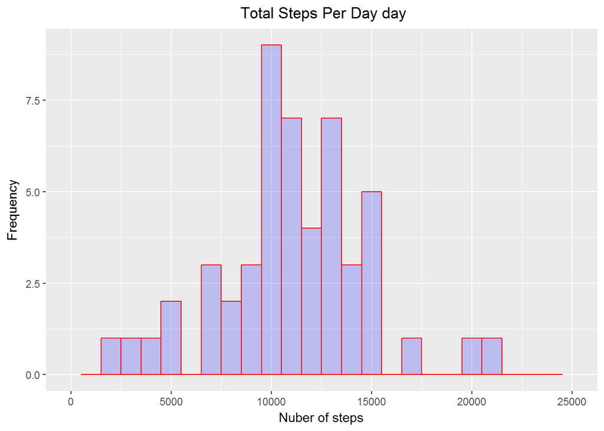

```r
library(ggplot2)

qplot(steps_per_day$steps,geom="histogram",binwidth=1000,main=" Total Steps Per Day day",xlab = "Nuber of steps",ylab ="Frequency", fill=I("blue"),col=I("red"),alpha=I(0.2),xlim=c(0,25000))+theme(plot.title = element_text(hjust = 0.5))
```

____________________________________________________________________________________________________________________________________

```r
activitymean<-mean(steps_per_day$steps,na.rm = TRUE)

activitymedian<-median(steps_per_day$steps,na.rm = TRUE)
```

### Lets see, what is daily average activity pattern ?

- Calculate average steps for each interval for all days.
- Plot the Average Number Steps per Day by Interval.
- Find interval with most average steps.

[figure not shown]

```r
Avg_steps_per_inetrval<-aggregate(steps~interval,data=activity,FUN = mean)
max_interval <- Avg_steps_per_inetrval[which.max(Avg_steps_per_inetrval$steps),1]

qplot(x=Avg_steps_per_inetrval$interval,y= Avg_steps_per_inetrval$steps,geom="line",size= "0.5",main="Average Steps Per Interval All Days",xlab = "Nuber of steps",ylab ="Frequency",col=I("red"),alpha=I(0.2),xlim=c(0,2000))+theme(plot.title = element_text(hjust = 0.5))
```

**The 5 minute interval from all the days with most average steps is 835.**

### Imputing missing values

- Presence of NA days can give us wrong information about the data analysis. It can produce bias summary and other statistical results.
- Here we are going to treat missing values by :
1. calculating total number of NA’s in a row.
2. Change the NA’s with mean or median values.

```r
missing <- nrow(activity[is.na(activity$steps),])

# Replace each missing value with the mean value of its 5-minute interval

change <- function(steps, interval) {
    filled <- NA
    if (!is.na(steps))
        filled <- c(steps)
    else
        filled <- (Avg_steps_per_inetrval[Avg_steps_per_inetrval$interval==interval, "steps"])
    return(filled)
}


Newdata <-activity
Newdata $steps <- mapply(change, Newdata$steps, Newdata$interval)
```

The total number of steps with NA’s is 2304.

All of the missing values are filled in with mean value for that 5-minute interval.

**Create a new dataset that is equal to the original dataset but with the missing data filled in.**

```r
total_steps<- tapply(Newdata$steps, Newdata$date, FUN=sum)
```